# Air Pollution-Related Mortality and Income

Author

Flavia Marsico

# 1 Introduction

In 2020, The Institute for Health Metrics and Evaluation (IHME), in its Global Burden of Disease study, provided estimates of the number of deaths attributed to a range of risk factors for disease.The study determined that air pollution- the combination of outdoor and indoor particulate matter and ozone- is one of the leading risk factors for death and one of the world’s largest health and environmental issues.In particular,in low-income countries, air pollution is often very near the top of the list or even the leading risk factor.This memo aims to provide a comprehensive report on the change in air pollution related mortality over time and show how air pollution differently affects countries according to their net national income

# 2 Data

# 3 Maps for the Whole World

First, I create a Cloropleth map of the world using the wolrd shapefile to visualize the share of deaths attributed to air pollution in 2019.

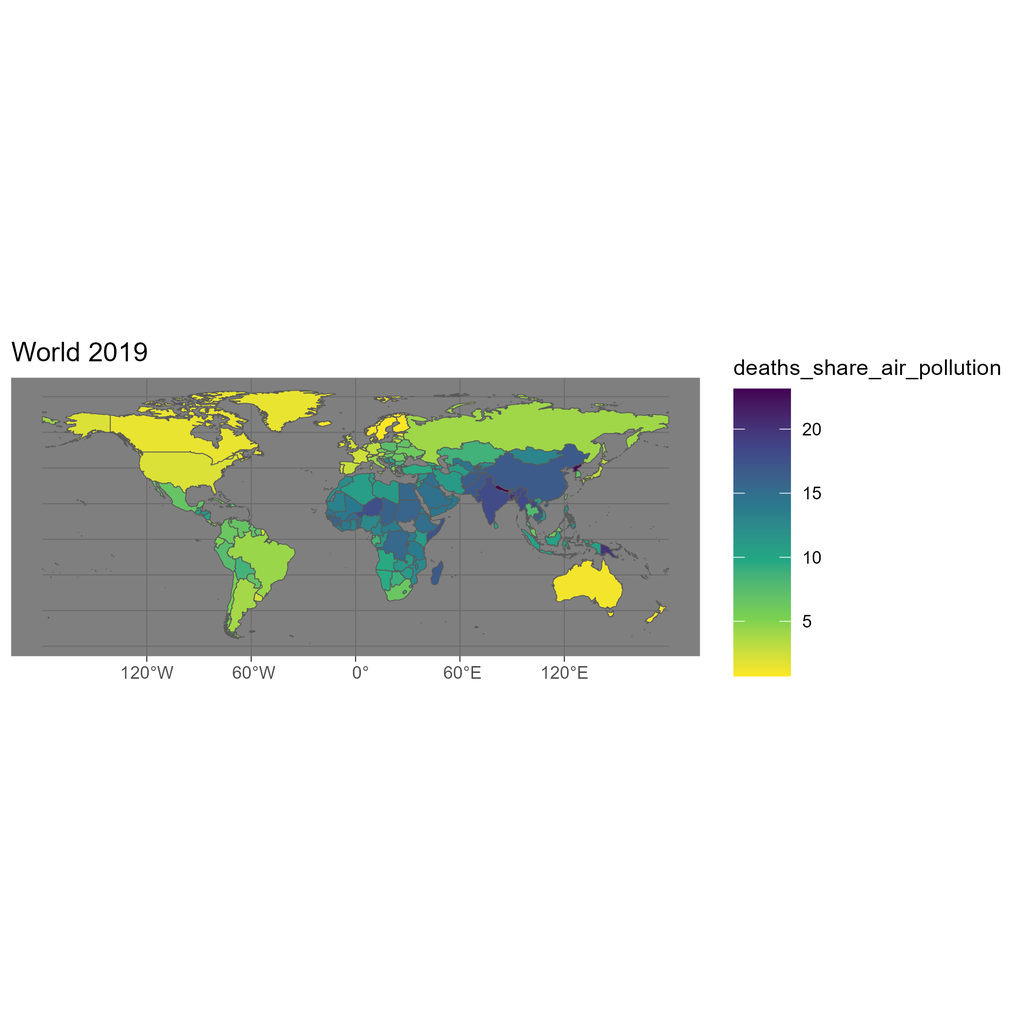

From this map it is possible to look at the countries with the highest and lowest share of deaths attributed to air pollution. The minimum values are around 5% and below whereas the highest reach around 20% in 2019. Let’s compare this map with 1990.

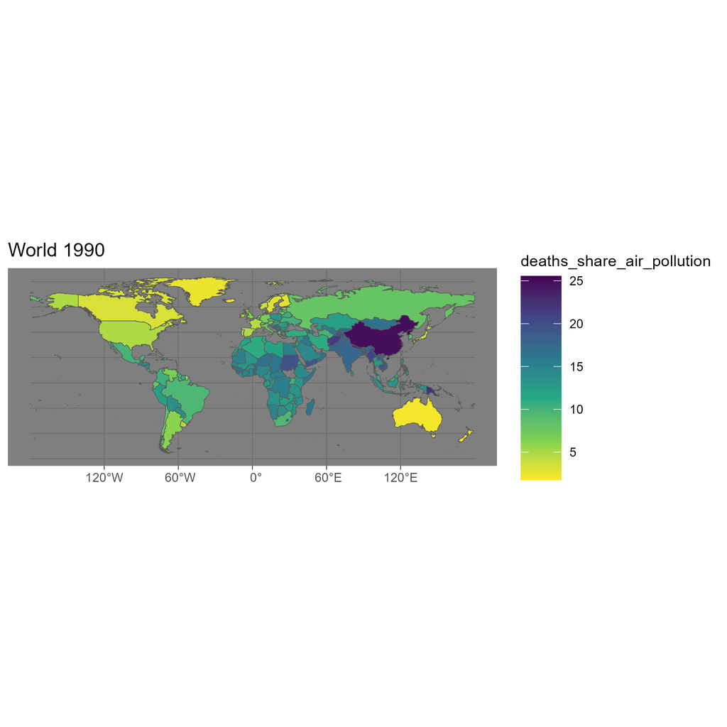

In 1990 the share of deaths attributed to air pollution was higher with values reaching up to 25% and slightly above.Looking at this map, one of the countries that stands out for its high percentage share is China.

Let’s take a closer look at how China’s share of deaths attributed to air pollution has changed from 1990 until 2019.

# 4 Map China 1990 vs 2019

- China 1990 vs China 2019

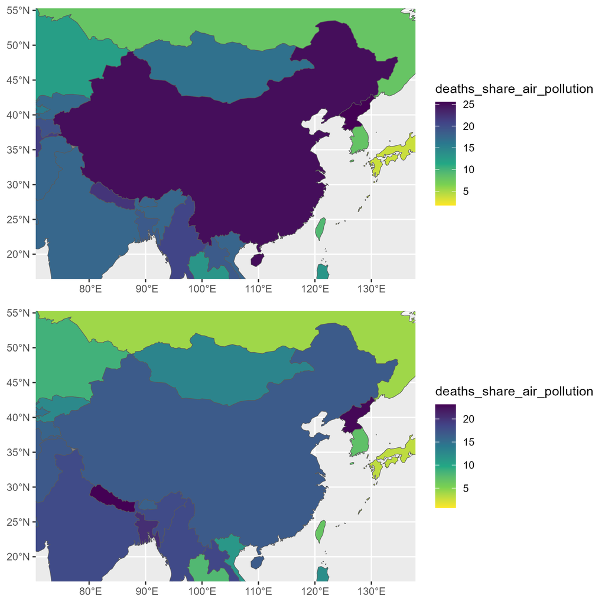

By looking at these two images, we notice that the share of deaths attributed to air pollution in china has decreased, although not extremely significantly.Similarly, countries such as the United States and Russia show a decreasing trend in deaths attributed to air pollution over time.

In order to have a more precise and clear representation of how the share of deaths by air pollution has changed over time, I use a time trend plot with data on the estimated annual number of deaths attributed to air pollution per 100,000 people.

# 5 Time Trend

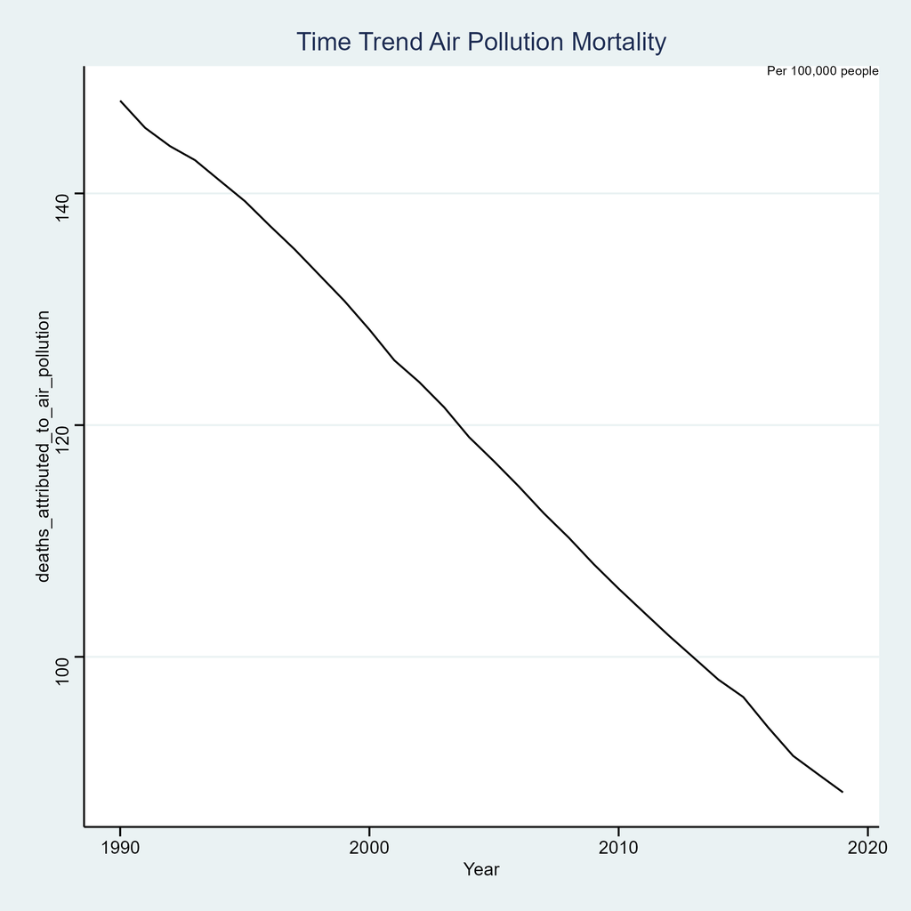

Vizualizing the time trend we clearly notice a steady decrease in the number of deaths atributed to air pollution from 1990 until 2019.According to a research conducted by Our Wolrd in Data,this decline has been primarily driven by improvements in indoor air pollution rather than outdoor. The latter has indeed decreased more modestly.

After determining that air pollution related mortality has decreased over time, I use a barplot that relates the estimated annual number of deaths attributed to air pollution per 100,000 people to the Net National Income per capita of each country in the world.After subsetting each country into high, middle or low income group I plot the data to highlight where most of the deaths attributed to air pollution occur.

# 6 Income and Air Pollution Mortality

Income Plot Air Pollution Mortality

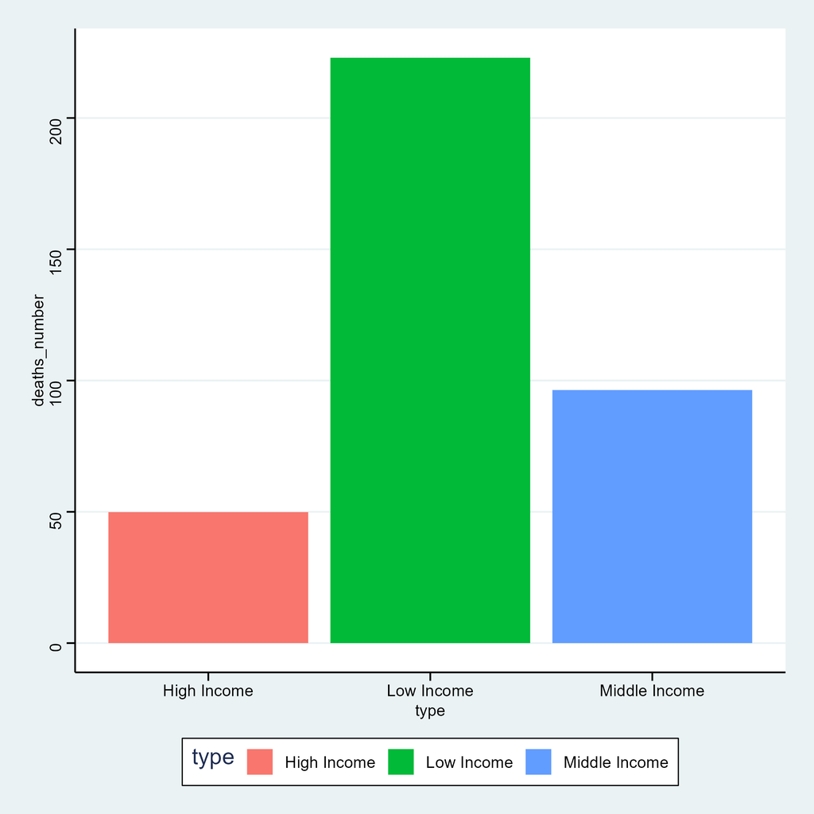

The barplot shows that the number of deaths is quite significantly higher in low income countries, followed by middle income countries and lastly high income countries.According to Our Wolrd In Data, the burden of air pollution tends to be greater across both low and middle-income countries for two reasons: indoor pollution rates tend to be high in low-income countries due to a reliance on solid fuels for cooking, and outdoor air pollution tends to increase as countries industrialize and shift from low to middle incomes.

## 6.1 Income and Air Pollution Mortality Time Animation

[figure not shown]

# 7 Conclusion

# 8 Appendix

This is a technical appendix for the operations performed to create this memo.

## 8.1 Part 1: Reading the data and Loading Libraries

```r
# Step 1: Loading relevant libraries
library(dplyr)
library(ggplot2)
library("sf")
#Step 2: reading the data
setwd("C:/Users/hp/OneDrive/Desktop/project_flavia/data")
air_poll<-read.csv("share-deaths-air-pollution.csv")
sf_use_s2(FALSE)
```

```
Spherical geometry (s2) switched off
```

```r
world <- read_sf(dsn = "./world_shp/world.shp")
world<-st_simplify(world,  dTolerance = 0.05)
```

## 8.2 Creating the Cloropleth Maps

```r
#Step3: Subsetting the data for the year 2019
air_poll_2019<-subset(air_poll, Year== 2019)

#Step4: Change the name of the variable at the found index
variable_index <- which(colnames(air_poll_2019) == "Share.of.total.deaths.that.are.from.all.causes.attributed.to.air.pollution..in.both.sexes.aged.age.standardized")

colnames(air_poll_2019)[variable_index] <- "deaths.share"

#Step5: Calculating average air pollution deaths share in 2019 by country
air_poll_2019<-air_poll_2019%>%
  group_by(Code, Entity)%>%
  summarize(deaths_share_air_pollution=mean(deaths.share))
#Step5: Removing countries with not code
air_poll_2019<-subset(air_poll_2019, air_poll_2019$Code!="")
# Step 6: Merging the data
merged<-left_join(world, air_poll_2019, by = c("adm0_a3" = "Code"))
#Step7: Mapping
library(viridis)
world_2019<-ggplot() +
    geom_sf() +
    geom_sf(data = merged, aes(fill = deaths_share_air_pollution))+
    scale_fill_viridis_c(option = "viridis",
                       direction = -1)+
  theme_dark()+
    ggtitle("World 2019")

#Step 8:Subsetting the data for the year 1990
air_poll_1990<-subset(air_poll, Year== 1990)
#Step 9: Change the name of the variable at the found index
variable_index <- which(colnames(air_poll_1990) == "Share.of.total.deaths.that.are.from.all.causes.attributed.to.air.pollution..in.both.sexes.aged.age.standardized")

colnames(air_poll_1990)[variable_index] <- "deaths.share"

#Step10: Calculating average deaths share in 1990 by county
air_poll_1990<-air_poll_1990%>%
  group_by(Code, Entity)%>%
  summarize(deaths_share_air_pollution=mean(deaths.share))
#Step11: Removing countries with not code
air_poll_1990<-subset(air_poll_1990, air_poll_1990$Code!="")
#Step12: Merging the data
merged2<-left_join(world, air_poll_1990, by = c("adm0_a3" = "Code"))
#Step13: Mapping
library(viridis)
world_1990<-ggplot() +
    geom_sf() +
    geom_sf(data = merged2, aes(fill = deaths_share_air_pollution))+
    scale_fill_viridis_c(option = "viridis",
                       direction = -1)+
  theme_dark()+
    ggtitle("World 1990")
```

## 8.3 Part 2: Mapping China for Comparison

```r
#Step14: Filter geometries for Cjina
china <- world[world$admin == "China", ]

#Step15: Extract bounding box coordinates
bbox_coords <- st_bbox(china)

#Step16: Extract max and min latitude and longitude
max_lat <- bbox_coords["ymax"]
min_lat <- bbox_coords["ymin"]
max_lon <- bbox_coords["xmax"]
min_lon <- bbox_coords["xmin"]

#Step17:Mapping
china_1990<-ggplot() +
    geom_sf() +
    geom_sf(data = merged2, aes(fill = deaths_share_air_pollution))+
    scale_fill_viridis_c(option = "viridis",
                       direction = -1)+
  coord_sf(xlim = c(min_lon, max_lon ),
           ylim = c(min_lat, max_lat))
```

```r
china_2019<-ggplot() +
    geom_sf() +
    geom_sf(data = merged, aes(fill = deaths_share_air_pollution))+
    scale_fill_viridis_c(option = "viridis",
                       direction = -1)+
  coord_sf(xlim = c(min_lon, max_lon ),
           ylim = c(min_lat, max_lat))
```

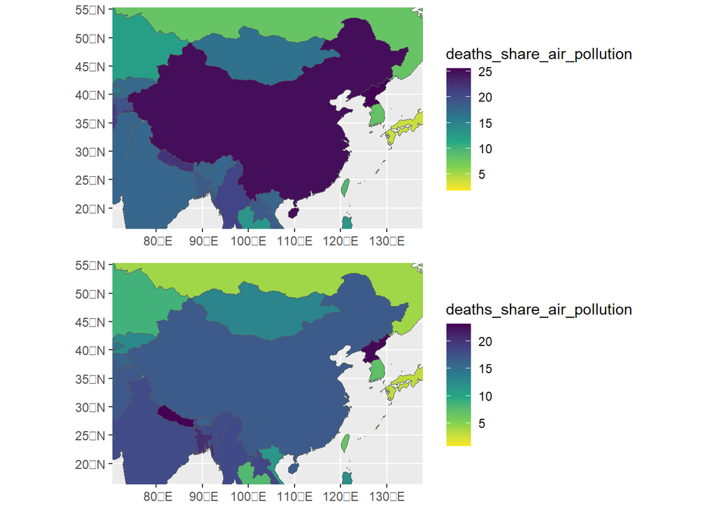

```r
#Step18:Arranging images for comparison
library(gridExtra)
china_comparison<-grid.arrange(china_1990, china_2019, nrow = 2)
```

## 8.4 Time Trend

```r
#Step19:Reading the data
death_rates_from_air_pollution<-read.csv("./data/death-rates-from-air-pollution (1).csv")
#Step20:Changing variable's name
variable_index <- which(colnames(death_rates_from_air_pollution) == "Deaths.that.are.from.all.causes.attributed.to.air.pollution.per.100.000.people..in.both.sexes.aged.age.standardized")
colnames(death_rates_from_air_pollution)[variable_index] <- "deaths.share"
#Step21:Calculating the average number of deaths per 100,00 people over time
death_from_pollution_over_time<-death_rates_from_air_pollution%>%
  group_by(Year)%>%
  dplyr::summarize(deaths_attributed_to_air_pollution = mean(deaths.share))

#Step22:Mapping
library(ggthemes)
time_trend<-ggplot(death_from_pollution_over_time, aes(x = Year, y = deaths_attributed_to_air_pollution)) +
  geom_line() +
   annotate("text", x = Inf, y = Inf, label = "Per 100,000 people", hjust = 1, vjust = 1, size = 2.5) +
  theme_stata()+
  ggtitle("Time Trend Air Pollution Mortality")
```

## 8.5 Part 3: Reationship between Income and Air Pollution Related Mortality

```r
#Step23:Reading Data
updated_income<-read.csv("./data/income/updated_income.csv")

#Step24: Get column names with the "X" prefix
x_columns <- grep("^X", colnames(updated_income), value = TRUE)

#Step25: Remove the "X" prefix from each column name
new_column_names <- sub("^X", "", x_columns)

#Step26 Rename the columns
colnames(updated_income)[grep("^X", colnames(updated_income))] <- new_column_names

library(tidyr)
#Step27:Pivot Longer the data
updated_income_long <- pivot_longer(updated_income,
                                    cols = starts_with(c("1960", "1961", "1962", "1963", "1964", "1965",
                                                        "1966", "1967", "1968", "1969", "1970", "1971",
                                                        "1972", "1973", "1974", "1975", "1976", "1977",
                                                        "1978", "1979", "1980", "1981", "1982", "1983",
                                                        "1984", "1985", "1986", "1987", "1988", "1989",
                                                        "1990", "1991", "1992", "1993", "1994", "1995",
                                                        "1996", "1997", "1998", "1999", "2000", "2001",
                                                        "2002", "2003", "2004", "2005", "2006", "2007",
                                                        "2008", "2009", "2010", "2011", "2012", "2013",
                                                        "2014", "2015", "2016", "2017", "2018", "2019",
                                                        "2020", "2021")),
                                    names_to = "Year",
                                    values_to = "net_national_income_per_capita")

#Step28: Removing the years 2022 and 2023
income_long <- updated_income_long %>%
  select(-matches("2022|2023"))
#Step29:Omitting missing values
income_long<-na.omit(income_long)

library(dplyr)

#Step30:Subset the dataset death_rates_from_air_pollution_1
air_pollution_deaths <- subset(death_rates_from_air_pollution, select = c("Entity", "Year", "deaths.share"))

#Step31:Subset the imcome_long dataset
final_income <- subset(income_long, select = c("Country.Name", "Year", "net_national_income_per_capita"))
#Step32:Convert the variable Year to numeric in final_income dataset
final_income$Year <- as.numeric(final_income$Year)

#Step33:Merge the two datasets
income_merged <- left_join(air_pollution_deaths, final_income, by = c("Entity" = "Country.Name", "Year" = "Year"))
```

```r
#Step34:Subsetting Low Income Countries
low_income_countries <- c(
  "Afghanistan", "Bangladesh", "Benin", "Burkina Faso", "Burundi",
  "Central African Republic", "Chad", "Comoros", "Congo, Dem. Rep.", "Chile",
  "Congo, Rep.", "Côte d’Ivoire", "Eritrea", "Ethiopia", "Gambia, The",
  "Ghana", "Guinea", "Guinea-Bissau", "Haiti", "Honduras", "India",
  "Indonesia", "Kenya", "Kyrgyz Republic", "Lesotho", "Liberia",
  "Madagascar", "Malawi", "Mali", "Mauritania", "Mozambique",
  "Myanmar", "Nepal", "Niger", "Nigeria", "Occupied Palestinian Territories",
  "Pakistan", "Papua New Guinea", "Rwanda", "Senegal", "Sierra Leone",
  "Solomon Islands", "Somalia", "South Sudan", "Sri Lanka", "Sudan",
  "Syrian Arab Republic", "Tajikistan", "Tanzania", "Timor-Leste",
  "Togo", "Uganda", "Vietnam", "Yemen, Rep.", "Zambia", "Zimbabwe"
)
```

```r
#Step35:Subsetting high income countries
high_income_countries <- c(
  "Australia", "Denmark", "Iceland", "Norway", "United States",
  "Ireland", "Luxembourg", "Singapore", "Switzerland", "Bermuda",
  "Germany", "Belgium", "Cayman Islands","Czechia", "Qatar", "Sweden",
  "Canada", "Israel","Kuwait","Portugal" ,"Liechtenstein", "San Marino", "United Arab Emirates","Slovenia",
  "Netherlands", "Bahrain","Oman")
```

```r
#Step36:Subsetting middle income countries
middle_income_countries <- c(
  "Palau", "Bulgaria", "Venezuela", "Costa Rica", "China", "Russia",
  "Saint Lucia", "Seychelles", "Malaysia", "Argentina", "Maldives", "Mexico",
  "Turkey", "Montenegro", "Mauritius", "Kazakhstan", "Serbia",
  "Saint Vincent and the Grenadines", "Greece","Grenada", "Dominican Republic", "Cuba",
  "Dominica", "Brazil", "Bosnia and Herzegovina", "Gabon", "Botswana",
  "Marshall Islands", "Libya", "Thailand", "Belarus", "Tuvalu", "Turkmenistan",
  "South Africa", "Albania", "Peru", "North Macedonia", "Belize", "Colombia",
  "Ecuador", "Armenia", "Paraguay", "Jamaica", "Azerbaijan", "Georgia",
  "Moldova", "Fiji", "Guatemala", "Iraq", "Equatorial Guinea", "Namibia",
  "Lebanon", "Suriname", "Tonga", "El Salvador", "Palestine","Latvia","Lituania","Marocco", "Indonesia","Angola","Algeria", "Barbados", "Bolivia", "Cambodia","Cote d'Ivoire","Croatia","Cyprus","Estonia","Nicaragua","Eswatini", "Guyana","Panama","Romania","Hungary","Jordan","Samoa","Trinidad and Tobago","Tunisia","Uzbekistan","Uruguay"
)
```

```r
#Step37:Omitting NA's
income_merged<-na.omit(income_merged)
#Step38:Categorizing countries in income_merged into different types based on their Income
income_merged$type[income_merged$Entity  %in% low_income_countries]<-"Low Income"
income_merged$type[income_merged$Entity  %in% high_income_countries]<-"High Income"
income_merged$type[income_merged$Entity  %in% middle_income_countries]<-"Middle Income"

#Step39: Calculating Averages death rates
library(dplyr)
averages_pollution_death<-income_merged%>%
  group_by(type)%>%
  dplyr::summarize(deaths_number=mean(deaths.share, na.rm=TRUE))
```

```r
#Step40:Plotting
library(ggthemes)
income_plot<-ggplot(averages_pollution_death, aes(x = type,
                 y = deaths_number,
                 fill = type)) +
  geom_col()+
  theme_stata()
```

## 8.6 Creating the animation for Income and Air Pollution Mortality Relationship

```
`geom_line()`: Each group consists of only one observation.
ℹ Do you need to adjust the group aesthetic?
```

```
`geom_line()`: Each group consists of only one observation.
ℹ Do you need to adjust the group aesthetic?
```

[figure not shown]

```r
#Step41:Creating the animation
library(gganimate)
library("av")
library("magick")
library("gifski")
library(gganimate)
time_plot<-ggplot(income_merged, aes(x = net_national_income_per_capita, y = deaths.share)) +
   geom_line()+
    labs(title = 'Net National Income: {frame_along}',
       x = 'Net National Income Per Capita',
       y = 'Death attributed to air pollution') +
  transition_reveal(net_national_income_per_capita)
animate(time_plot, fps = 5)
```